# Exploratory Coyote Analysis

K.Rivera karivera@uri.edu

April 22th, 2021

# Coyotes in Rhode Island: An Introduction

## As one of the most adaptable apex carnivores, coyotes have stirred contention across human dominated landscapes. In Rhode Island, coyote-human relationships have been vastly unexplored despite local’s high interest in their presence and activity. Information on human-coyote interactions as well as what drives people’s value of coyotes may be an important tool for managing coyotes and people’s relationship with coyotes in the state. Through an online survey, I gathered data on people’s demographics, relationship and interactions with coyotes, as well as other variables which may be important in predicting people’s value of coyotes.

# Hypothesis:

## 1) Older individuals will have more negative view of coyotes

## 2) Individuals with more education will have a more positive view of coyotes

## 3) Pet owners with pet-coyote interactions will have a more negative view of coyotes

## 4) Livestock owners with livestock-coyote interactions will have a more negative view of coyotes

# Setting up for data cleaning

```r
# clean Up R--------------------------------------------------------------------
rm(list=ls())
gc() #garbage collection
```

```
##          used (Mb) gc trigger (Mb) max used (Mb)
## Ncells 413569 22.1     862301 46.1   638648 34.2
## Vcells 760681  5.9    8388608 64.0  1631685 12.5
```

```r
# Libraries---------------------------------------------------------------------
library(tidyverse) # data manipulation (includes ggplot and forcats)
library(lubridate) # dates
library(dplyr)
library(psych)
library(janitor)
library(corrr)
```

# Read in raw data and rename columns; this is mostly categorical data that was collected using ‘Qualtrics Survey Software’

```r
# Read in data------------------------------------------------------------------
setwd("C:/Users/Kim Rivera/Documents/Coyotes/Questionnaire Data/live survey/r_data")
coyote_raw = read_csv("Coyote Questionnaire_final_dataset.csv") # OG survey data

# Organize data-----------------------------------------------------------------
coyote <- coyote_raw %>% mutate(date = round_date(mdy_hm(`End Date`))) %>%
  select(-c(1,2,4,7,8,10:13, 16, 17, 158:162))
coyote<- coyote[-c(1:12),] # 'Official' survey started Oct 6

## Rename columns---------------------------------------------------------------
names <- colnames(coyote)
colnames(coyote) <- c("response.type", "progress","time","ID","lat","lon","resident","years.residency","not.resident",
                      "not.resident.others","months.RI", "months.RI.text","county","town","town.text",
                      "street","street.text","outdoor","outdoor.text","nature.person","image.relation.nature",
                      "important.ecosystem","beneficial.humans", "beneficial.wildlife","important.hunters","risk.humans","risk.pets",
                      "negative.wildlife","diseases","reaction","reaction.text","fearful","problem.when",
                      "problem.when.text","coyote.population","all.removed","problem.removed","problem.relocated",
                      "all.sterilized","problem.sterilized","preventive.measures","more.research",
                      "education.program","footholds","native","ri.past.10.years","litter.food",
                      "nocturnal","carnivores","10.human.rabies.year","furbearers","NAMWC","place.coyotes",
                      "place.should","fq.hear","fq.see","fq.see.pups","fq.see.roadkill","fq.see.scat",
                      "fq.see.neighbour","fq.see.eat", "fq.aggressive","fq.fed","pet.owner","pet","pet.text","risk.outdoor.cat",
                      "encounter.outdoor.cat","attack.outdoor.cat","missing.outdoor.cat","kill.outdoor.cat",
                      "risk.large.dog","encounter.large.dog","attack.large.dog","missing.large.dog",
                      "kill.large.dog","risk.small.dog","encounter.small.dog","attack.small.dog",
                      "missing.small.dog","kill.small.dog","risk.pet","encounter.pet","attack.pet",
                      "missing.pet","kill.pet","livestock.owner","livestock","livestock.text",
                      "risk.goat","encounter.goat","attack.goat","missing.goat","kill.goat",
                      "risk.sheep","encounter.sheep","attack.sheep","missing.sheep","kill.sheep",
                      "risk.poultry","encounter.poultry","attack.poultry","missing.poultry","kill.poultry",
                      "risk.pig","encounter.pig","attack.pig","missing.pig","kill.pig","risk.cattle",
                      "encounter.cattle","attack.cattle","missing.cattle","kill.cattle","risk.other",
                      "encounter.other","attack.other","missing.other","kill.other",
                      "protect.from.coyote","measures","measures.text","take.care","not.to.worry",
                      "human.ingenuity","plenty.resources","equal.rights","laws.of.nature","humans.rule","delicate.balance",
                      "envt.cata","age","ethnicity","ethnicity.text","education","household.income",
                      "gender","share","seek.info","contact.envt.mgt.nat.resources","contact.police","contact.uri",
                      "contact.wildlife.center","contact.nature.center","contact.animal.control",
                      "contact.envt.mgt.law.enforce","date")
```

## Since this data is mostly categorical, let’s convert character columns to factors and create a new column, ‘flagged’ for data points (participants) that do not meet survey standards

```r
# Convert all characters to factors, can change back to numeric, etc later if needed
coyote = coyote %>% mutate_if(sapply(coyote, is.character), as.factor)

# create new column which ID's unusable data, 0 = good data, 1's = flagged
# start with survey.type and flag 'Survey Preview' and 'Spam'
coyote = coyote %>% mutate(flagged = ifelse(response.type == "Spam", 1,
                                            ifelse(response.type == "Survey Preview", 1, 0)))
# Now remove these from our cleaned dataset
coyote = filter(coyote, flagged != 1)
```

## Let’s go through our variables of interest (and realted variables) and clean up the data

### Age

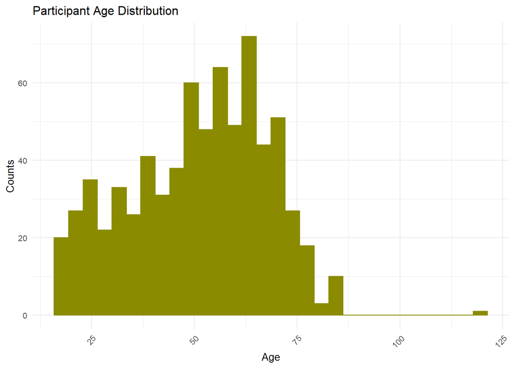

```r
## Check Out Age Distribution
ggplot(coyote, aes(x=age)) + geom_histogram(fill ='yellow4', color = 'yellow4') +
  labs(x = "Age", y = "Counts", title = "Participant Age Distribution") +
  theme_minimal() +
  theme(legend.position="none",
        axis.text.x = element_text(angle = 45, hjust = 1),
        text = element_text(family = "LM Roman 10 Bold", size=10))
```

```r
# Hmm, I believe it is unlikely a participant is over 110 y/o. Either this was entered wrong or perhaps the
# participant doesn't want to share their age, or did not take this survey seriously. Let's look at the data
# point and investigate other responses.
view = coyote %>% filter(age > 100) # it looks like other data is legitimate, we will therefor change age to NA
coyote <- coyote %>% mutate(age = na_if(age, 120))
```

### Gender

```r
levels(coyote$gender)
```

```
##  [1] "Apache attack helicopter"
##  [2] "Bi curious Buffalo."
##  [3] "boy"
##  [4] "Dude"
##  [5] "f"
##  [6] "F"
##  [7] "Femail"
##  [8] "femal"
##  [9] "female"
## [10] "Female"
## [11] "Female, non-binary/fluid"
## [12] "Genderqueer/Nonbinary"
## [13] "I don't believe in gender"
## [14] "is that still a thing? female"
## [15] "m"
```

[output cut: 16 more lines]

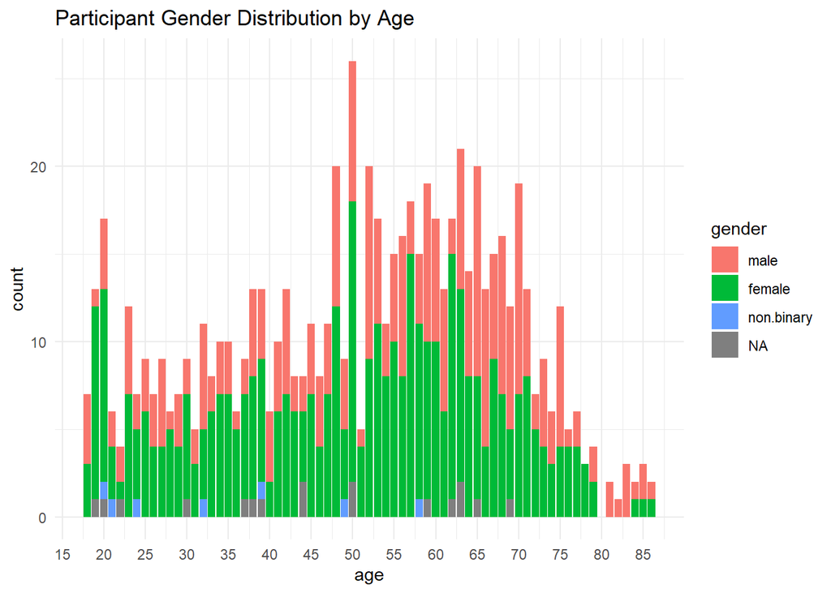

```r
# Let's convert unusable entries to NA
coyote <- coyote %>% mutate(gender = recode_factor(gender, "Apache attack helicopter" = NA_character_)) %>%
  mutate(gender = recode_factor(gender, "mmm, no." = NA_character_)) %>%
  mutate(gender = recode_factor(gender, "I don't believe in gender" = NA_character_)) %>%
  mutate(gender = recode_factor(gender, "Bi curious Buffalo." = NA_character_))

# collapse and correct level labels
coyote <- coyote %>% mutate(gender = fct_collapse(gender,
                                                  male = c("m", "M", "Male", "boy", "MALE","Make", "Dude",
                                                           "male.  However it is interesting that the previous question offered selections but this question did not.",
                                                           "Man", "masculine", "male"),
                                                  female = c("Femail", "More or less female", "femal", "woman", "Woman", "F", "f", "Female", "female", "is that still a thing? female"),
                                                  non.binary = c("Female, non-binary/fluid" ,"non binary", "Genderqueer/Nonbinary", "Non-Binary","Non-binary","non-binary")))

## Check Out Distribution
ggplot(coyote, aes(x= age, fill = gender)) + geom_bar() +
  labs(title = 'Participant Gender Distribution by Age')+
  scale_x_continuous(breaks = seq(10, 100, by = 5))+
theme_minimal()
```

### Education

```r
levels(coyote$education)
```

```
## [1] "2-year college degree or certificate"
## [2] "4-year college Degree"
## [3] "Elementary School"
## [4] "Graduate Degree"
## [5] "High School"
## [6] "Technical or vocational degree"
```

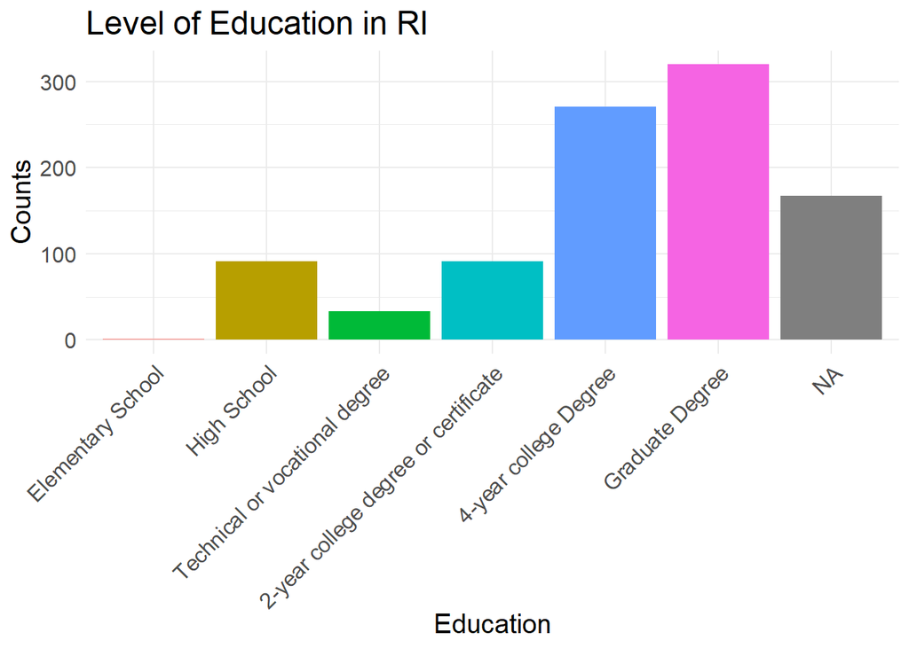

```r
# relevel education
coyote <- coyote %>% mutate(education = factor(education)) %>%
  mutate(education = fct_relevel(education, c("Elementary School", "Middle School","High School",  "Technical or vocational degree", "2-year college degree or certificate", "4-year college Degree", "Graduate Degree")))

ggplot(coyote, aes(education, fill = education)) +
  geom_bar() +
  labs(x = "Education", y = "Counts", title = "Level of Education in RI") +
  theme_minimal() +
  theme(legend.position="none",
        axis.text.x = element_text(angle = 45, hjust = 1),
        text = element_text(family = "LM Roman 10 Bold", size=15))
```

### Household Income

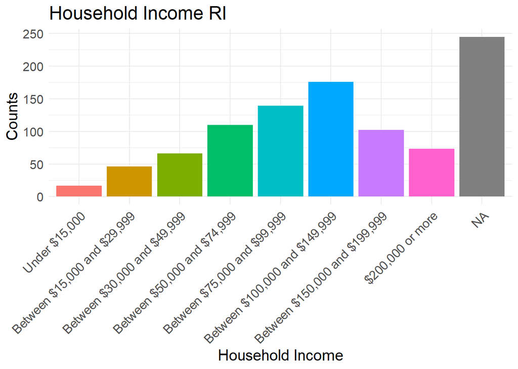

```r
# relevel income
coyote <- coyote %>% mutate(household.income = factor(household.income)) %>%
  mutate(household.income = fct_relevel(household.income, c("Under $15,000", "Between $15,000 and $29,999","Between $30,000 and $49,999", "Between $50,000 and $74,999","Between $75,000 and $99,999","Between $100,000 and $149,999","Between $150,000 and $199,999", "$200,000 or more" )))

ggplot(coyote, aes(household.income, fill = household.income)) +
  geom_bar() +
  labs(x = "Household Income", y = "Counts", title = "Household Income RI") +
  theme_minimal() +
  theme(legend.position="none",
        axis.text.x = element_text(angle = 45, hjust = 1),
        text = element_text(family = "LM Roman 10 Bold", size=15))
```

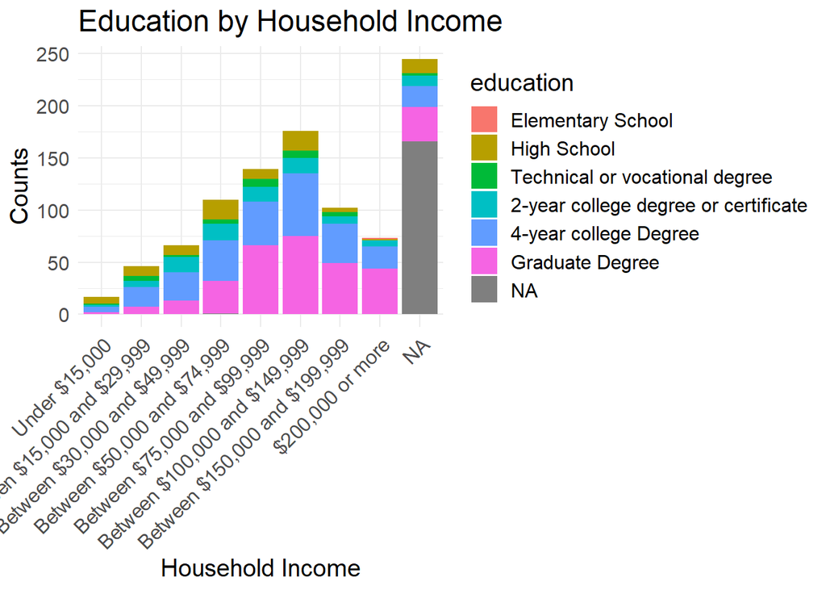

```r
# Let's see if income is related to education
ggplot(coyote, aes(household.income, fill = education)) +
  geom_bar() +
  labs(x = "Household Income", y = "Counts", title = "Education by Household Income") +
  theme_minimal() +
  theme(axis.text.x = element_text(angle = 45, hjust = 1),
        text = element_text(family = "LM Roman 10 Bold", size=15))
```

### County

```r
levels(factor(coyote$county))
```

```
## [1] "Bristol"
## [2] "I do not wish to share this information"
## [3] "Kent"
## [4] "Newport"
## [5] "Providence"
## [6] "Washington"
```

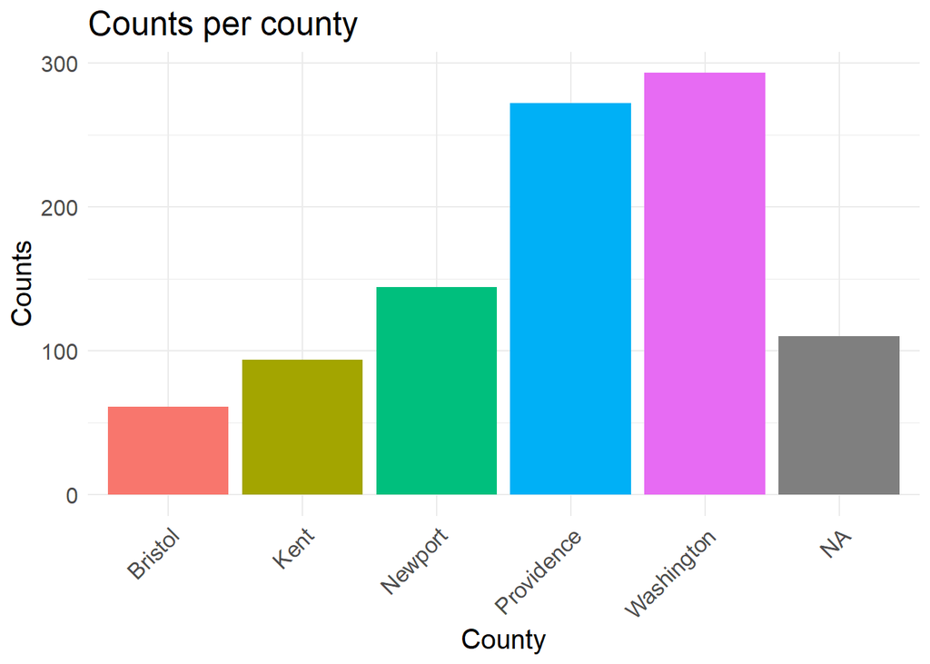

```r
coyote <- mutate(coyote,county = replace(county, county=="I do not wish to share this information","Not_shared"))

# get the levels ordered by counts
levels <- coyote %>%
  group_by(county) %>%
  summarize(count=n()) %>%
  arrange(count) %>%
  select(county) %>%
  as_vector()

coyote %>%
  mutate(county = factor(county, levels = levels)) %>%
  ggplot(aes(x = county, fill = county)) +
  geom_bar() +
  labs(x = "County", y = "Counts", title = "Counts per county") +
  theme_minimal() +
  theme(legend.position="none",
        axis.text.x = element_text(angle = 45, hjust = 1),
        text = element_text(family = "LM Roman 10 Bold", size=15))
```

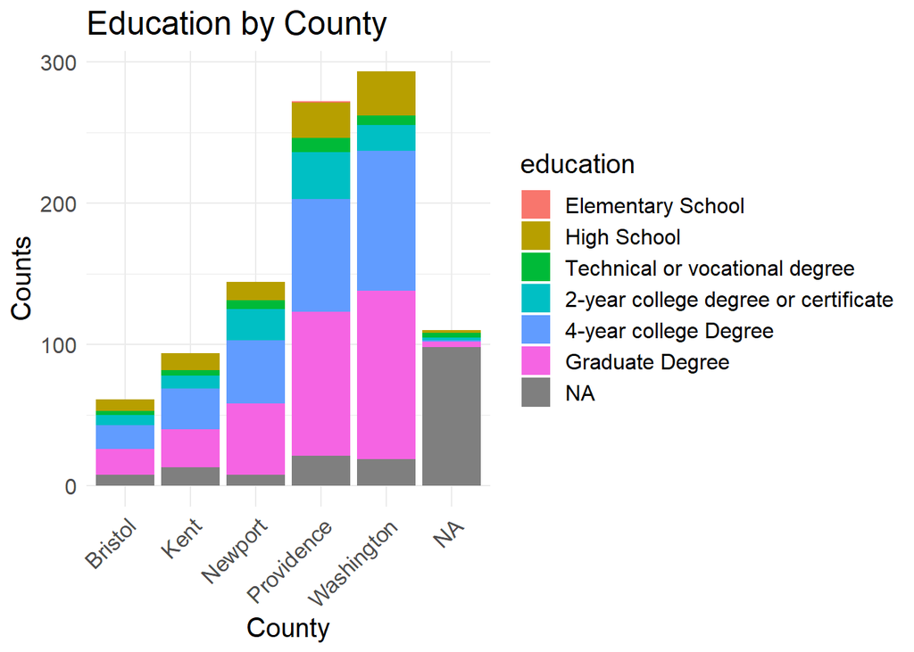

```r
# Let's see if county is related to education
ggplot(coyote, aes(county, fill = education)) +
  geom_bar() +
  labs(x = "County", y = "Counts", title = "Education by County") +
  theme_minimal() +
  theme(axis.text.x = element_text(angle = 45, hjust = 1),
        text = element_text(family = "LM Roman 10 Bold", size=15))
```

### Pet Demographics

```r
coyote <- coyote %>%
  mutate(pet.owner = ifelse(str_detect(pet.owner,"(?i)yes"),1,0))

# correct non-informative levels to NAs
coyote <- coyote %>% mutate(pet = recode_factor(pet, "Tamed Coyote" = NA_character_)) %>%
  mutate(gender = recode_factor(pet, "Two" = NA_character_)) %>%
  mutate(gender = recode_factor(pet, "I have 9 indoor pets of various sizes and species" = NA_character_))%>%
  mutate(gender = recode_factor(pet, "All indoors and never unattended" = NA_character_))

# Make selection wider data
coyote <- coyote %>%
  mutate(pet.outdoor.cat = ifelse(str_detect(pet,"(?i)Outdoor.*Cat"),1,0),
         pet.small.dog = ifelse(str_detect(pet,"(?i)Small.*dog"),1,0),
         pet.lrg.dog = ifelse(str_detect(pet,"Large.*dog"),1,0))

# Change data from factor to character for mutate and case_when
coyote <- coyote %>%
  mutate(pet = as.character(pet))
class(coyote$pet)
```

```
## [1] "character"
```

```r
coyote <- coyote %>%
  mutate(pet.text = as.character(pet.text))
class(coyote$pet.text)
```

```
## [1] "character"
```

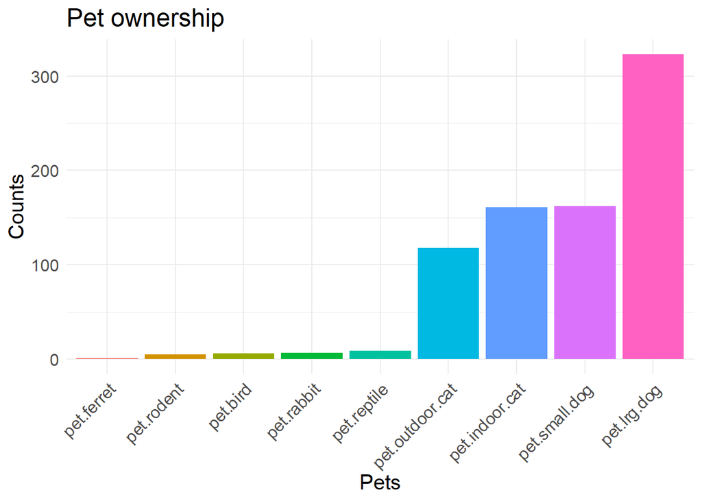

```r
# categorize the input text from participants
coyote <- coyote %>%
  mutate(pet.text = case_when(pet.text %in% c("2 cats","cats (indoor only)",
                                              "i am active in cat rescue and have previously had outdoor feral cats. I moved them indoors.",
                                              "Lost a cat to coyotes now indoor only") ~ "indoor cat",
                              pet.text %in% c("2 dogs","my dog is 45#, which I consider medium sized.") ~ "large dogs",
                              pet.text %in% c("3cats, 1. Corgi") ~ "outdoor cat, Corgi",
                              pet.text %in% c("cat goes out only if I am in yard") | str_detect(pet.text,"(?i)indoor/outdoor|cat.*night") ~ "int/out cat",
                              TRUE ~ pet.text)) %>%
  mutate(pet.indoor.cat = ifelse(str_detect(pet.text,"(?i)indoor.*cat|house.*cat|door.*cat|indoor.*animal|inside.*cat"),1,0),
         pet.outdoor.cat = replace(pet.outdoor.cat,str_detect(pet.text,"(?i)outdoor.*cat|stray.*cat|out.*cat"),1),
         pet.small.dog = replace(pet.small.dog,str_detect(pet.text,"(?i)Corgi|small.*dog"),1),
         pet.lrg.dog = replace(pet.lrg.dog,str_detect(pet.text,"(?i)lab|Medium-sized.*dog|lbdog|Border|large.*dog"),1),
         pet.bird = ifelse(str_detect(pet.text, "(?i)bird|macaw|parrot|cockatoo"),1,0),
         pet.rabbit = ifelse(str_detect(pet.text, "(?i)\\brabbit\\b|house.*rabbit|bunny|indoor.*rabbits"),1,0),
         pet.reptile = ifelse(str_detect(pet.text, "(?i)reptile|snake|herp|lizard|tortoise|turtle"),1,0),
         pet.ferret = ifelse(str_detect(pet.text, "(?i)ferret"),1,0),
         pet.rodent = ifelse(str_detect(pet.text, "(?i)gerbil|guinea.*pig|hamter"),1,0))

# Lets check out population of pet owners
levels <- coyote %>%
  pivot_longer(pet.outdoor.cat:pet.rodent, names_to="index",values_to="value") %>%
  filter(value == 1) %>%
  group_by(index) %>%
  summarize(count=n()) %>%
  arrange(count) %>%
  select(index) %>%
  as_vector()

# data with including others answers
coyote %>%
  pivot_longer(pet.outdoor.cat:pet.rodent, values_to="value",names_to="index") %>%
  filter(value==1) %>%
  mutate(index = factor(index, levels=levels)) %>%
  ggplot(aes(x = index, fill = index)) +
  geom_bar() +
  labs(x = "Pets", y = "Counts", title = "Pet ownership") +
  theme_minimal() +
  theme(legend.position="none",
        axis.text.x = element_text(angle = 45, hjust = 1),
        text = element_text(family = "LM Roman 10 Bold", size=15))
```

### Pet-Coyote Interactions

#### This is defined as people experiencing: an encounter between their pet and a coyote, an attack on their pet by a coyote or a death of pet by a coyote

```r
# Create new column for having had any pet-coyote interaction (only focus on outdoor cats and dogs for now)
pet.int = coyote %>%
  select(encounter.outdoor.cat:kill.small.dog ) %>% # select all columns about pet interactions with coyotes
  select(-contains("risk")) %>%
  mutate_all(~case_when(. == "Yes" ~ 1,
                        . == "No" ~ 0)) %>% # change yes/no for 1/0
  add_column(pet.int = rowSums(., na.rm=TRUE)) %>% # sum all the interactions
  mutate(pet.int = ifelse(pet.int > 0,"Yes","No")) # # if more than one interaction, assign Yes

## Add the column to the dataset
coyote$pet.int <- pet.int$pet.int
coyote <- coyote %>%
  mutate(pet.int = replace(pet.int, pet.owner == "No", NA))
# Change pet.int from yes/no, to 1/0
coyote = coyote %>%
  mutate(pet.int = case_when(
    pet.int == "Yes" ~ 1,
    pet.int == "No" ~ 0))
```

### Livestock Demographics

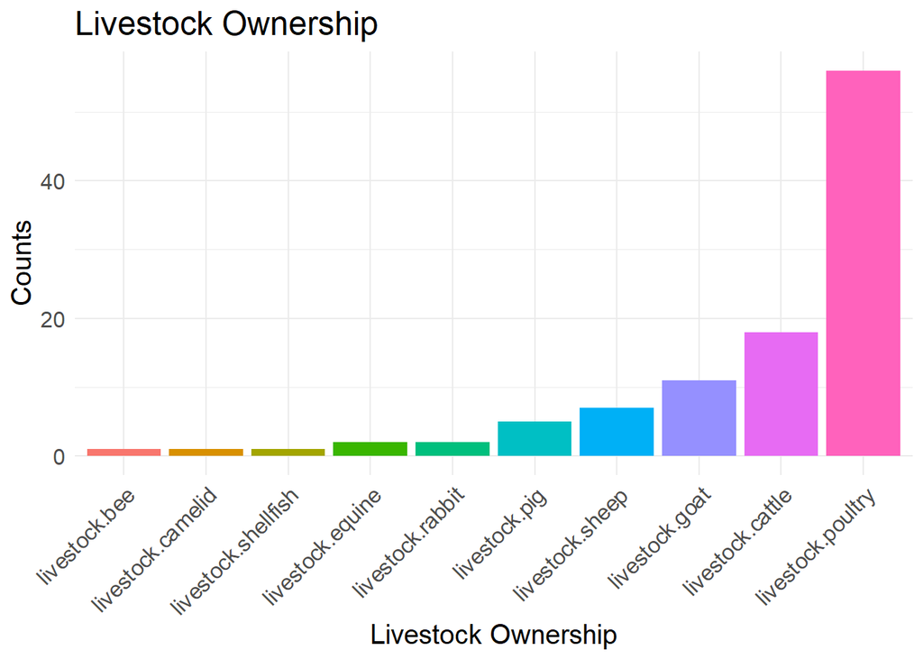

```r
# Make selection wider data
coyote <- coyote %>%
  mutate(livestock.cattle = ifelse(str_detect(livestock,"(?i)cattle"),1,0),
         livestock.goat = ifelse(str_detect(livestock,"(?i)goat"),1,0),
         livestock.poultry = ifelse(str_detect(livestock,"(?i)poultry"),1,0),
         livestock.pig = ifelse(str_detect(livestock,"(?i)pig"),1,0),
         livestock.sheep = ifelse(str_detect(livestock,"(?i)sheep"),1,0))

coyote <- coyote %>%
  mutate(livestock.bee = ifelse(str_detect(livestock.text, "(?i)bees"),1,0),
         livestock.camelid = ifelse(str_detect(livestock.text, "(?i)llama|alpaca"),1,0),
         livestock.poultry = replace(livestock.poultry,str_detect(livestock.text,"(?i)peacock|hen"),1),
         livestock.equine = ifelse(str_detect(livestock.text,"(?i)horse|donkey"),1,0),
         livestock.cattle = replace(livestock.cattle,str_detect(livestock.text,"(?i)cattle|goat"),1),
         livestock.shellfish = ifelse(str_detect(livestock.text, "(?i)quoahog"),1,0),
         livestock.rabbit = ifelse(str_detect(livestock.text, "(?i)outdoor.*rabbits|rabbits"),1,0))

# counts by levels
levels <- coyote %>%
  pivot_longer(livestock.cattle:livestock.rabbit, names_to="index",values_to="value") %>%
  filter(value == 1) %>%
  group_by(index) %>%
  summarize(count=n()) %>%
  arrange(count) %>%
  select(index) %>%
  as_vector()

# all data
coyote %>%
  pivot_longer(livestock.cattle:livestock.rabbit, names_to="index",values_to="value") %>%
  mutate(index = factor(index, levels = levels)) %>%
  filter(value == 1) %>%
  ggplot(aes(x = index, fill = index)) +
  geom_bar() +
  labs(x = "Livestock Ownership", y = "Counts", title = "Livestock Ownership") +
  theme_minimal() +
  theme(legend.position="none",
        axis.text.x = element_text(angle = 45, hjust = 1),
        text = element_text(family = "LM Roman 10 Bold", size=15))
```

### Livestock-Coyote Interactions

#### This is defined as people experiencing: an encounter between their livestock and a coyote, an attack on their livestock by a coyote or a death of livestock by a coyote

```r
## Create new column for having had any pet-coyote interaction (only focus on outdoor cats and dogs for now)
livestock.int = coyote %>%
  select(encounter.goat:kill.cattle) %>% # select all columns about livestock interactions with coyotes
  select(-contains("risk")) %>%
  mutate_all(~case_when(. == "Yes" ~ 1,
                        . == "No" ~ 0)) %>% # change yes/no for 1/0
  add_column(livestock.int = rowSums(., na.rm=TRUE)) %>% # sum all the interactions
  mutate(livestock.int = ifelse(livestock.int > 0,"Yes","No")) # # if more than one interaction, assign Yes

## Add the column to the dataset
coyote$livestock.int <- livestock.int$livestock.int
coyote <- coyote %>%
  mutate(livestock.int = replace(livestock.int, pet.owner == "No", NA))
# Change livestock.int from yes/no, to 1/0
coyote = coyote %>%
  mutate(livestock.int = case_when(
    livestock.int == "Yes" ~ 1,
    livestock.int == "No" ~ 0))
```

### Human-Coyote Relationships

##### Lets focus on participants thoughts on coyotes, e.g. ranking of benefits and risks of coyotes

```r
# Starting with benefits strong disagree [1] -> strong agree [5]
coyote <- coyote  %>%
  mutate(important.ecosystem = fct_relevel(important.ecosystem, c("Strongly Disagree", "Disagree", "Neither agree nor disagree",  "Agree", "Strongly Agree")))
coyote <- coyote  %>%
  mutate(beneficial.humans = fct_relevel(beneficial.humans, c("Strongly Disagree", "Disagree", "Neither agree nor disagree",  "Agree", "Strongly Agree")))
coyote <- coyote  %>%
  mutate(beneficial.wildlife = fct_relevel(beneficial.wildlife, c("Strongly Disagree", "Disagree", "Neither agree nor disagree",  "Agree", "Strongly Agree")))
coyote <- coyote  %>%
  mutate(important.hunters = fct_relevel(important.hunters, c("Strongly Disagree", "Disagree", "Neither agree nor disagree",  "Agree", "Strongly Agree")))

# Now risks strong disagree [5] -> strongly agree [1]
coyote <- coyote  %>%
  mutate(risk.humans = fct_relevel(risk.humans, c("Strongly Agree", "Agree", "Neither agree nor disagree", "Disagree", "Strongly disagree")))
coyote <- coyote  %>%
  mutate(risk.pets = fct_relevel(risk.pets, c("Strongly Agree", "Agree", "Neither agree nor disagree",  "Disagree", "Strongly disagree")))
coyote <- coyote  %>%
  mutate(negative.wildlife = fct_relevel(negative.wildlife, c("Strongly Agree", "Agree", "Neither agree nor disagree",  "Disagree", "Strongly disagree")))
coyote <- coyote  %>%
  mutate(diseases = fct_relevel(diseases, c("Strongly Agree", "Agree", "Neither agree nor disagree",  "Disagree", "Strongly disagree")))
```

# Coyote Data Analysis

## We first use a Cronbach’s Alpha to determine the correlation between all questions used to assess participant’s value of coyotes. This is done by unclassifying factorized Likert data. The resulting alpha allows us to determine the reliability of multi-item scales

```r
coyote.attitude = coyote %>%
  select(c(important.ecosystem, beneficial.humans, beneficial.wildlife, important.hunters,
           risk.humans, risk.pets, negative.wildlife, diseases)) %>%
  mutate_at(c("important.ecosystem", "beneficial.humans", "beneficial.wildlife", "important.hunters",
              "risk.humans", "risk.pets", "negative.wildlife", "diseases"), ~unclass(.))

# This test will tell us how well items here correlate
# ideally want an alpha coefficient of 0.08 or higher for short lists of items
psych::alpha(coyote.attitude)
```

```
##
## Reliability analysis
## Call: psych::alpha(x = coyote.attitude)
##
##   raw_alpha std.alpha G6(smc) average_r S/N    ase mean   sd median_r
##       0.84      0.84    0.87      0.39 5.2 0.0077  3.1 0.72      0.4
##
##  lower alpha upper     95% confidence boundaries
## 0.82 0.84 0.85
##
##  Reliability if an item is dropped:
##                     raw_alpha std.alpha G6(smc) average_r S/N alpha se var.r
## important.ecosystem      0.80      0.80    0.83      0.36 3.9   0.0098 0.046
## beneficial.humans        0.80      0.80    0.83      0.37 4.0   0.0095 0.047
## beneficial.wildlife      0.79      0.79    0.82      0.35 3.8   0.0100 0.045
## important.hunters        0.87      0.87    0.89      0.49 6.7   0.0064 0.030
## risk.humans              0.82      0.82    0.84      0.39 4.4   0.0087 0.056
## risk.pets                0.82      0.82    0.85      0.40 4.6   0.0086 0.060
## negative.wildlife        0.81      0.81    0.84      0.37 4.1   0.0094 0.058
## diseases                 0.84      0.84    0.87      0.43 5.2   0.0079 0.059
##                     med.r
## important.ecosystem  0.39
## beneficial.humans    0.40
## beneficial.wildlife  0.39
## important.hunters    0.44
## risk.humans          0.36
## risk.pets            0.39
## negative.wildlife    0.39
## diseases             0.44
##
##  Item statistics
##                       n raw.r std.r r.cor r.drop mean   sd
## important.ecosystem 843  0.82  0.82  0.82   0.74  3.9 1.03
## beneficial.humans   840  0.79  0.79  0.80   0.71  3.8 1.03
## beneficial.wildlife 839  0.84  0.84  0.86   0.77  3.7 1.08
## important.hunters   837  0.33  0.33  0.17   0.15  2.5 1.07
## risk.humans         843  0.71  0.71  0.66   0.59  3.0 1.18
## risk.pets           842  0.68  0.68  0.62   0.56  2.2 1.02
## negative.wildlife   841  0.77  0.77  0.73   0.68  3.5 1.03
## diseases            842  0.54  0.55  0.45   0.41  2.5 0.91
##
## Non missing response frequency for each item
##      miss
## [1,]    1
```

```r
# this gives us a raw alpha of .84, a .8 correlation is considered sufficient for short lists
```

## Kendall’s Rank Coefficient

### Kendall’s tau coefficient is a non-parametric correlation test used to determine the relationship between individual value questions and our hypothesis. Kendall’s rank coefficient uses ranked pairs to determine the association direction (positive or negative) and strength (stronger as tau approaches ±1).

```r
# Let's look at our hypothesis and start by analyzing the ordinal level data, education
# Hyp 2) Individuals with more education will have a more positive view of coyotes

kendall = coyote %>% select(c(beneficial.humans, beneficial.wildlife, important.ecosystem, important.hunters,
                              diseases, negative.wildlife, risk.humans, risk.pets, education)) %>%
  mutate_all(~unclass(.))


eco.ed = cor.test(kendall$important.ecosystem, kendall$education, method="kendall")
ben.hum.ed = cor.test(kendall$beneficial.humans, kendall$education, method="kendall")
ben.wild.ed = cor.test(kendall$beneficial.wildlife, kendall$education, method="kendall")
hunt.ed = cor.test(kendall$important.hunters, kendall$education, method="kendall")
dis.ed = cor.test(kendall$diseases, kendall$education, method="kendall")
neg.wild.ed = cor.test(kendall$negative.wildlife, kendall$education, method="kendall")
risk.hum.ed = cor.test(kendall$risk.humans, kendall$education, method="kendall")
risk.pet.ed = cor.test(kendall$risk.pets, kendall$education, method="kendall")

eco.ed
```

```
##
##  Kendall's rank correlation tau
##
## data:  kendall$important.ecosystem and kendall$education
## z = 1.7534, p-value = 0.07954
## alternative hypothesis: true tau is not equal to 0
## sample estimates:
##        tau
## 0.05288065
```

```r
ben.hum.ed
```

```
##
##  Kendall's rank correlation tau
##
## data:  kendall$beneficial.humans and kendall$education
## z = 1.0058, p-value = 0.3145
## alternative hypothesis: true tau is not equal to 0
## sample estimates:
##        tau
## 0.03024785
```

```r
ben.wild.ed
```

```
##
##  Kendall's rank correlation tau
##
## data:  kendall$beneficial.wildlife and kendall$education
## z = 0.50808, p-value = 0.6114
## alternative hypothesis: true tau is not equal to 0
## sample estimates:
##        tau
## 0.01518317
```

```r
hunt.ed
```

```
##
##  Kendall's rank correlation tau
##
## data:  kendall$important.hunters and kendall$education
## z = -2.3669, p-value = 0.01794
## alternative hypothesis: true tau is not equal to 0
## sample estimates:
##         tau
## -0.07072631
```

```r
dis.ed
```

```
##
##  Kendall's rank correlation tau
##
## data:  kendall$diseases and kendall$education
## z = 2.4304, p-value = 0.01508
## alternative hypothesis: true tau is not equal to 0
## sample estimates:
##        tau
## 0.07368765
```

```r
neg.wild.ed
```

```
##
##  Kendall's rank correlation tau
##
## data:  kendall$negative.wildlife and kendall$education
## z = 2.7786, p-value = 0.00546
## alternative hypothesis: true tau is not equal to 0
## sample estimates:
##        tau
## 0.08296331
```

```r
risk.hum.ed
```

```
##
##  Kendall's rank correlation tau
##
## data:  kendall$risk.humans and kendall$education
## z = 2.5934, p-value = 0.009504
## alternative hypothesis: true tau is not equal to 0
## sample estimates:
##        tau
## 0.07683174
```

```r
risk.pet.ed
```

```
##
##  Kendall's rank correlation tau
##
## data:  kendall$risk.pets and kendall$education
## z = 2.3323, p-value = 0.01969
## alternative hypothesis: true tau is not equal to 0
## sample estimates:
##        tau
## 0.07029251
```

```r
# Hyp 3) Pet owners pet-coyote interactions will have a more negative view of coyotes

eco.pet = cor.test(kendall$important.ecosystem, coyote$pet.int, method="kendall")
ben.hum.pet = cor.test(kendall$beneficial.humans, coyote$pet.int, method="kendall")
ben.wild.pet = cor.test(kendall$beneficial.wildlife, coyote$pet.int, method="kendall")
hunt.pet = cor.test(kendall$important.hunters, coyote$pet.int, method="kendall")
dis.pet = cor.test(kendall$diseases, coyote$pet.int, method="kendall")
neg.wild.pet = cor.test(kendall$negative.wildlife, coyote$pet.int, method="kendall")
risk.hum.pet = cor.test(kendall$risk.humans, coyote$pet.int, method="kendall")
risk.pet.pet = cor.test(kendall$risk.pets, coyote$pet.int, method="kendall")

eco.pet
```

```
##
##  Kendall's rank correlation tau
##
## data:  kendall$important.ecosystem and coyote$pet.int
## z = -3.0033, p-value = 0.00267
## alternative hypothesis: true tau is not equal to 0
## sample estimates:
##         tau
## -0.09594076
```

```r
ben.hum.pet
```

```
##
##  Kendall's rank correlation tau
##
## data:  kendall$beneficial.humans and coyote$pet.int
## z = -1.7065, p-value = 0.08792
## alternative hypothesis: true tau is not equal to 0
## sample estimates:
##         tau
## -0.05431049
```

```r
ben.wild.pet
```

```
##
##  Kendall's rank correlation tau
##
## data:  kendall$beneficial.wildlife and coyote$pet.int
## z = -2.0625, p-value = 0.03916
## alternative hypothesis: true tau is not equal to 0
## sample estimates:
##         tau
## -0.06526791
```

```r
hunt.pet
```

```
##
##  Kendall's rank correlation tau
##
## data:  kendall$important.hunters and coyote$pet.int
## z = -0.9049, p-value = 0.3655
## alternative hypothesis: true tau is not equal to 0
## sample estimates:
##        tau
## -0.0286615
```

```r
dis.pet
```

```
##
##  Kendall's rank correlation tau
##
## data:  kendall$diseases and coyote$pet.int
## z = -1.1602, p-value = 0.246
## alternative hypothesis: true tau is not equal to 0
## sample estimates:
##         tau
## -0.03724585
```

```r
neg.wild.pet
```

```
##
##  Kendall's rank correlation tau
##
## data:  kendall$negative.wildlife and coyote$pet.int
## z = -2.3071, p-value = 0.02105
## alternative hypothesis: true tau is not equal to 0
## sample estimates:
##         tau
## -0.07298502
```

```r
risk.hum.pet
```

```
##
##  Kendall's rank correlation tau
##
## data:  kendall$risk.humans and coyote$pet.int
## z = -3.968, p-value = 7.249e-05
## alternative hypothesis: true tau is not equal to 0
## sample estimates:
##        tau
## -0.1245171
```

```r
risk.pet.pet
```

```
##
##  Kendall's rank correlation tau
##
## data:  kendall$risk.pets and coyote$pet.int
## z = -3.3716, p-value = 0.0007472
## alternative hypothesis: true tau is not equal to 0
## sample estimates:
##        tau
## -0.1076225
```

```r
# Hyp 4) Pet owners livestock-coyote interactions will have a more negative view of coyotes

eco.livestock = cor.test(kendall$important.ecosystem, coyote$livestock.int, method="kendall")
ben.hum.livestock = cor.test(kendall$beneficial.humans, coyote$livestock.int, method="kendall")
ben.wild.livestock = cor.test(kendall$beneficial.wildlife, coyote$livestock.int, method="kendall")
hunt.livestock = cor.test(kendall$important.hunters, coyote$livestock.int, method="kendall")
dis.livestock = cor.test(kendall$diseases, coyote$livestock.int, method="kendall")
neg.wild.livestock = cor.test(kendall$negative.wildlife, coyote$livestock.int, method="kendall")
risk.hum.livestock = cor.test(kendall$risk.humans, coyote$livestock.int, method="kendall")
risk.pet.livestock = cor.test(kendall$risk.pets, coyote$livestock.int, method="kendall")

eco.livestock
```

```
##
##  Kendall's rank correlation tau
##
## data:  kendall$important.ecosystem and coyote$livestock.int
## z = -0.2633, p-value = 0.7923
## alternative hypothesis: true tau is not equal to 0
## sample estimates:
##          tau
## -0.008411096
```

```r
ben.hum.livestock
```

```
##
##  Kendall's rank correlation tau
##
## data:  kendall$beneficial.humans and coyote$livestock.int
## z = -1.774, p-value = 0.07607
## alternative hypothesis: true tau is not equal to 0
## sample estimates:
##         tau
## -0.05645956
```

```r
ben.wild.livestock
```

```
##
##  Kendall's rank correlation tau
##
## data:  kendall$beneficial.wildlife and coyote$livestock.int
## z = -1.2101, p-value = 0.2263
## alternative hypothesis: true tau is not equal to 0
## sample estimates:
##         tau
## -0.03829267
```

```r
hunt.livestock
```

```
##
##  Kendall's rank correlation tau
##
## data:  kendall$important.hunters and coyote$livestock.int
## z = 0.82953, p-value = 0.4068
## alternative hypothesis: true tau is not equal to 0
## sample estimates:
##        tau
## 0.02627435
```

```r
dis.livestock
```

```
##
##  Kendall's rank correlation tau
##
## data:  kendall$diseases and coyote$livestock.int
## z = -1.5685, p-value = 0.1168
## alternative hypothesis: true tau is not equal to 0
## sample estimates:
##         tau
## -0.05035506
```

```r
neg.wild.livestock
```

```
##
##  Kendall's rank correlation tau
##
## data:  kendall$negative.wildlife and coyote$livestock.int
## z = -2.4966, p-value = 0.01254
## alternative hypothesis: true tau is not equal to 0
## sample estimates:
##         tau
## -0.07898245
```

```r
risk.hum.livestock
```

```
##
##  Kendall's rank correlation tau
##
## data:  kendall$risk.humans and coyote$livestock.int
## z = -4.5105, p-value = 6.468e-06
## alternative hypothesis: true tau is not equal to 0
## sample estimates:
##        tau
## -0.1415413
```

```r
risk.pet.livestock
```

```
##
##  Kendall's rank correlation tau
##
## data:  kendall$risk.pets and coyote$livestock.int
## z = -1.3736, p-value = 0.1696
## alternative hypothesis: true tau is not equal to 0
## sample estimates:
##         tau
## -0.04384636
```

#### It’s clear, that looking at these ‘attitude’ scale questions individually, there are very weak positive and negative correlations. The strongest correlations are: risk to humans with pet interaction, risk to pets with pet interactions, and risk to humans with livestock interactions. All of these are negativelty correlated meaning as people have more pet and livestock interactions with coyotes, they view coyotes more negatively (because the ‘attitude’ scale goes form negative –> positive)

## Ordinal Regression

```r
# first organize the data and take the mean
kendall = kendall %>% rowwise() %>%
  mutate(coyote.attitude = mean(c(important.ecosystem, beneficial.humans, beneficial.wildlife, important.hunters)), na.rm = TRUE) %>%
  select(-na.rm)

# add this data back to original dataset
coyote$coyote.attitude <- kendall$coyote.attitude

# tell R how these attitudes rank
coyote <- coyote %>%
  mutate(coyote.attitude = ordered(coyote.attitude, levels = c("1", "1.5", "2","2.5","3","3.5","4","4.5","5")))

# This library is for ordinal regression analysis
library(MASS)
```

### Let’s run a few models

```r
# This includes all of our variables of interest
mod1 = polr(coyote.attitude ~ age + education + pet.int + livestock.int, data = coyote, method="logistic", Hess=TRUE)
AIC(mod1)
```

```
## [1] 1577.485
```

```r
#Let's try variations of these variables and compare AIC's
mod2 = polr(coyote.attitude ~ education + pet.int + livestock.int, data = coyote, method="logistic", Hess=TRUE)
AIC(mod2)
```

```
## [1] 1812.162
```

```r
mod3 = polr(coyote.attitude ~ age + pet.int + livestock.int, data = coyote, method="logistic", Hess=TRUE)
AIC(mod3)
```

```
## [1] 1586.35
```

```r
mod4 = polr(coyote.attitude ~ pet.int + livestock.int, data = coyote, method="logistic", Hess=TRUE)
AIC(mod4)
```

```
## [1] 1891.521
```

```r
AIC(mod1, mod2, mod3, mod4)
```

```
##      df      AIC
## mod1 16 1577.485
## mod2 15 1812.162
## mod3 11 1586.350
## mod4 10 1891.521
```

#### It appears the first model is our best fit, mod1, let’s explore that more

```r
summary(mod1)
```

```
## Call:
## polr(formula = coyote.attitude ~ age + education + pet.int +
##     livestock.int, data = coyote, Hess = TRUE, method = "logistic")
##
## Coefficients:
##                                                  Value Std. Error  t value
## age                                           -0.01168   0.005531 -2.11234
## educationHigh School                           1.17543   1.508568  0.77917
## educationTechnical or vocational degree        0.10357   1.527437  0.06781
## education2-year college degree or certificate  1.07104   1.502576  0.71281
## education4-year college Degree                 1.24234   1.486652  0.83566
## educationGraduate Degree                       1.15516   1.481792  0.77957
## pet.int                                       -0.33719   0.202449 -1.66553
## livestock.int                                 -0.29483   0.391045 -0.75395
##
## Intercepts:
##       Value   Std. Error t value
## 1|1.5 -3.2379  1.5481    -2.0914
## 1.5|2 -2.9152  1.5401    -1.8929
## 2|2.5 -2.1447  1.5282    -1.4034
## 2.5|3 -1.3693  1.5215    -0.8999
## 3|3.5 -0.2380  1.5205    -0.1565
## 3.5|4  0.6643  1.5216     0.4366
## 4|4.5  1.7513  1.5231     1.1498
## 4.5|5  3.1722  1.5318     2.0709
##
## Residual Deviance: 1545.485
## AIC: 1577.485
## (564 observations deleted due to missingness)
```

```r
coef(mod1) #extract model coef
```

```
##                                           age
##                                   -0.01168245
##                          educationHigh School
##                                    1.17543328
##       educationTechnical or vocational degree
##                                    0.10356884
## education2-year college degree or certificate
##                                    1.07104405
##                education4-year college Degree
##                                    1.24233973
##                      educationGraduate Degree
##                                    1.15516312
##                                       pet.int
##                                   -0.33718587
##                                 livestock.int
##                                   -0.29482858
```

```r
ctable = coef(summary(mod1))
p = pnorm(abs(ctable[, "t value"]), lower.tail = FALSE) * 2  ## add the p-values to the table
ctable = cbind(ctable, "p value" = p)
ctable
```

```
##                                                     Value  Std. Error
## age                                           -0.01168245 0.005530564
## educationHigh School                           1.17543328 1.508567730
## educationTechnical or vocational degree        0.10356884 1.527437098
## education2-year college degree or certificate  1.07104405 1.502576305
## education4-year college Degree                 1.24233973 1.486652270
## educationGraduate Degree                       1.15516312 1.481792088
## pet.int                                       -0.33718587 0.202449468
## livestock.int                                 -0.29482858 0.391045332
## 1|1.5                                         -3.23785552 1.548141771
## 1.5|2                                         -2.91517799 1.540069014
## 2|2.5                                         -2.14465144 1.528168155
## 2.5|3                                         -1.36927794 1.521537524
## 3|3.5                                         -0.23802347 1.520474796
## 3.5|4                                          0.66431184 1.521640989
## 4|4.5                                          1.75130146 1.523144493
## 4.5|5                                          3.17219288 1.531822766
##                                                   t value    p value
## age                                           -2.11234366 0.03465698
## educationHigh School                           0.77917170 0.43587858
## educationTechnical or vocational degree        0.06780563 0.94594036
## education2-year college degree or certificate  0.71280510 0.47596637
## education4-year college Degree                 0.83566262 0.40334473
## educationGraduate Degree                       0.77957166 0.43564304
## pet.int                                       -1.66553102 0.09580686
## livestock.int                                 -0.75394989 0.45087931
## 1|1.5                                         -2.09144639 0.03648807
## 1.5|2                                         -1.89288789 0.05837278
## 2|2.5                                         -1.40341325 0.16049364
## 2.5|3                                         -0.89993044 0.36815727
## 3|3.5                                         -0.15654549 0.87560307
## 3.5|4                                          0.43657593 0.66241892
## 4|4.5                                          1.14979338 0.25022898
## 4.5|5                                          2.07086156 0.03837174
```

### Interpretting our model

```r
ci <- confint(mod1)
exp(cbind(odd_ratio = coef(mod1), ci))
```

```
##                                               odd_ratio      2.5 %    97.5 %
## age                                           0.9883855 0.97769901  0.999139
## educationHigh School                          3.2395463 0.11301956 92.521153
## educationTechnical or vocational degree       1.1091221 0.03766371 32.508588
## education2-year college degree or certificate 2.9184249 0.10263648 82.641767
## education4-year college Degree                3.4637081 0.12449411 96.005669
## educationGraduate Degree                      3.1745412 0.11485023 87.415287
## pet.int                                       0.7137762 0.47940349  1.060754
## livestock.int                                 0.7446592 0.34508799  1.608199
```

#### This code provides the proportional odds ratio. This ratio allows us to interpret the odds participants will have a more positive or negative attitude of coyotes. Here we see that with increasing age and interactions between coyotes and livestock, participants odds of having a positive attitude towards coyotes decreases. Education varibales are harder to interpret although all odds are above 1, meaning they are more likely to have a postive attitude towards coyotes given education than the other variables (age and interactiosn betwen coyotes and pets & livestock)

# Exploratory Data Analysis

## We can also plot our variables of interest and see if we can find any obvious relationships between our independent variables of interest and peoples attitutes towards coyotes

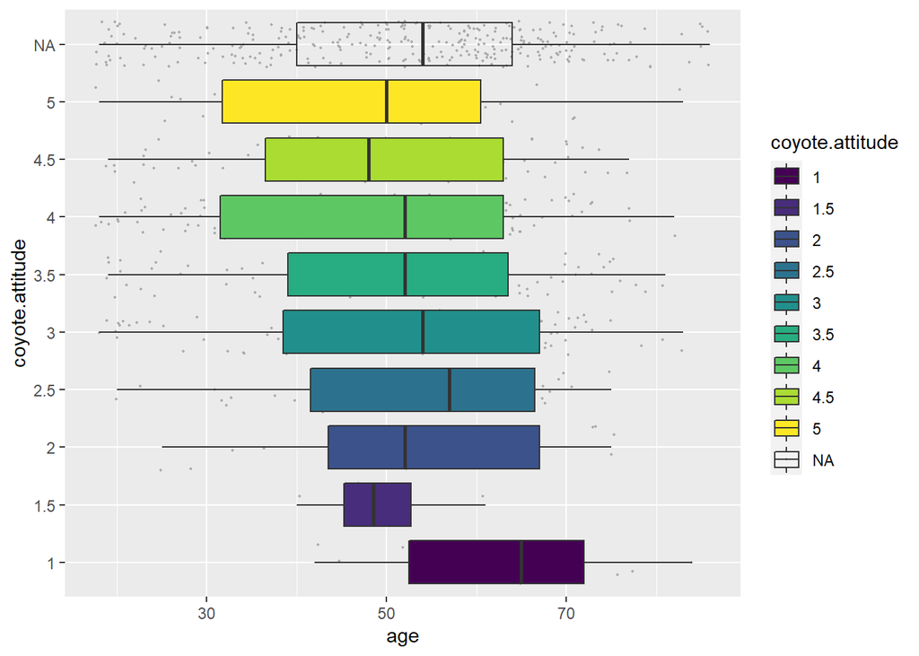

```r
coyote %>% filter(is.na(age)== FALSE) %>%
  ggplot(aes(x = age, y = coyote.attitude, fill = coyote.attitude))+
  geom_jitter(color = "darkgray", size = .3, alpha =.9)+
  geom_boxplot()
```

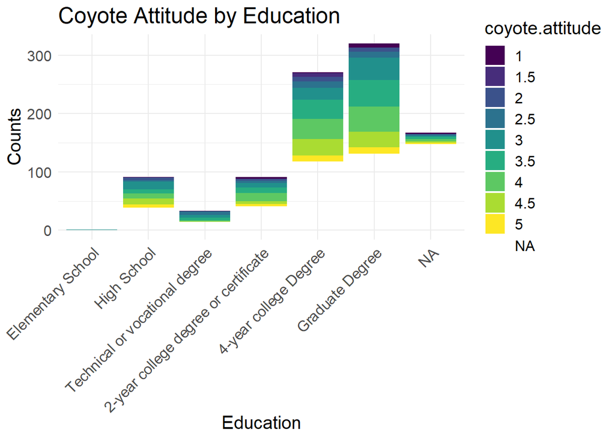

```r
ggplot(coyote, aes(education, fill = coyote.attitude)) +
  geom_bar() +
  labs(x = "Education", y = "Counts", title = "Coyote Attitude by Education") +
  theme_minimal() +
  theme(axis.text.x = element_text(angle = 45, hjust = 1),
        text = element_text(family = "LM Roman 10 Bold", size=15))
```

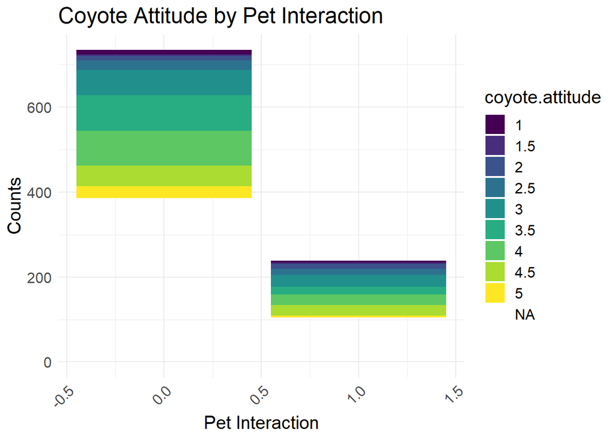

```r
ggplot(coyote, aes(pet.int, fill = coyote.attitude)) +
  geom_bar() +
  labs(x = "Pet Interaction", y = "Counts", title = "Coyote Attitude by Pet Interaction") +
  theme_minimal() +
  theme(axis.text.x = element_text(angle = 45, hjust = 1),
        text = element_text(family = "LM Roman 10 Bold", size=15))
```

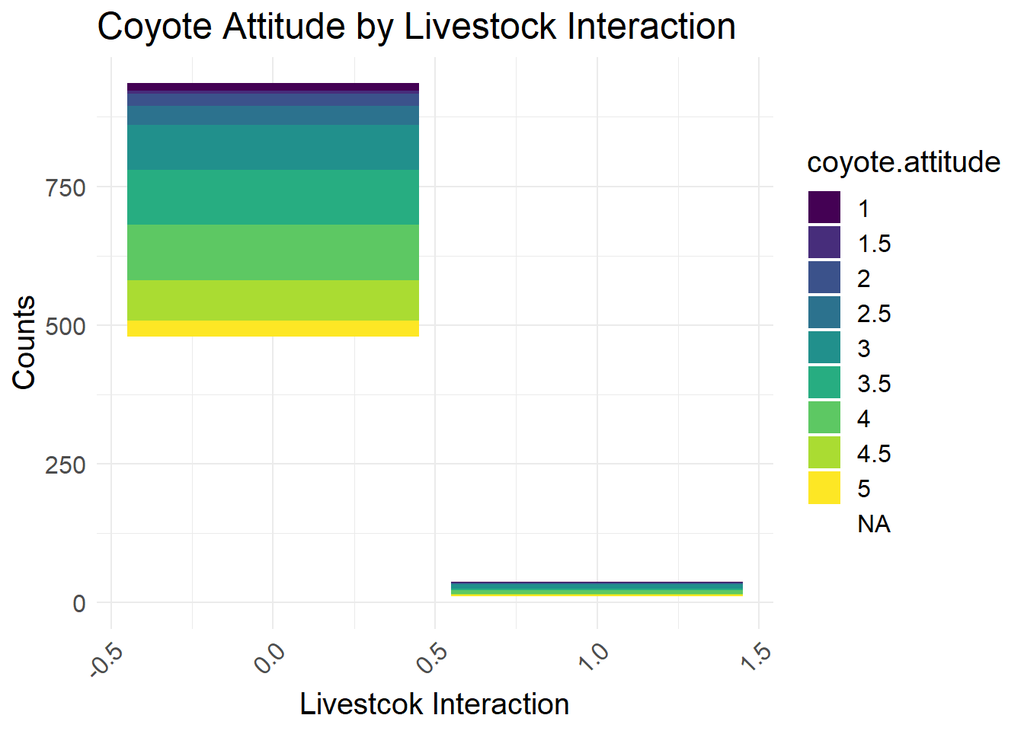

```r
ggplot(coyote, aes(livestock.int, fill = coyote.attitude)) +
  geom_bar() +
  labs(x = "Livestcok Interaction", y = "Counts", title = "Coyote Attitude by Livestock Interaction") +
  theme_minimal() +
  theme(axis.text.x = element_text(angle = 45, hjust = 1),
        text = element_text(family = "LM Roman 10 Bold", size=15))
```